# Qualitative Activity Recognition Course Project

Gary W. Deinert

Wednesday, September 23, 2015

#### This project is a review qualitatively assessing and providing feedback on weight lifting exercises. Activities are recorded and applied to a model evaluating the quality of the activity. Data collected is used in this report as a basis for a prediction model. We begin by loading the appropriate libraries (caret, ggplot2, and corrplot) to complete the evaluation. Data is loaded from the website into a local working directory prior to the beginning of this program.

```r
library(caret)
library(ggplot2)
library(corrplot)
setwd("C:/Users/Gary/Desktop/Data Science Specialzation/Machine Learning")
trainMaster = read.csv("pml-training.csv")
testMaster = read.csv("pml-testing.csv")
```

#### The training data set is preprocessed (manually) to achieve the following ‘clean up’: a) unnecessary / inappropriate variables with little model value are removed; b) Variables with 95% or greater “NA” values are eliminated as low-value input; c) Variables with near-zero variance providing little model value are removed; d) Highly correlated variables are reduced.

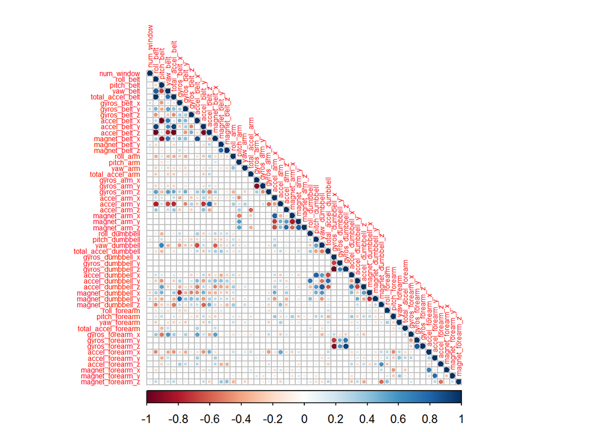

```r
workingDF <- trainMaster
workingDF <- workingDF[-c(1:5)]           ## Remove row.names, X, and timestamps
NAclear <- colSums(is.na(workingDF))/nrow(workingDF) < 0.95       ## Clear vars > 95% NA
remNAs <- NAclear[NAclear == TRUE]       ## Trace the removed variables
workingDF <- workingDF[NAclear]
nzv <- nearZeroVar(workingDF); workingDF <- workingDF[,-nzv]      # Remove near-zero var
corMatrix<- cor(workingDF[,-54])           ## remove highly correlated predictors
corrplot(corMatrix, type = "lower", tl.cex=0.5)
```

```r
removeCorr <- findCorrelation(corMatrix, cutoff=0.90, verbose=FALSE)
workingDF <- workingDF[,-removeCorr]      ## removed highly correlated variables
```

#### Data is then split into a working training set and a working test set at a 70%-30% split. Not knowing the best model construct to choose, we have run 4 different alternatives: K-Nearest Neighbors (KNN), a Gradient Boosting Model (GBM), a Support Vector Machine model (SVM), and a Random Forest model (RF).

#### Cross Validation: We have set up our training model control as a 4-fold cross validation (“cv”) method (4 resamples of the data).

```r
## split into training and test datasets
inTrain <- createDataPartition(y=workingDF$classe,p=0.7,list=FALSE)
workingTrain <- workingDF[inTrain,]
workingTest <- workingDF[-inTrain,]
dim(workingTrain); dim(workingTest)
```

```
## [1] 13737    47
```

```
## [1] 5885   47
```

```r
modelControl <- (trainControl(method="cv", number=4)) ## Training: 4-fold cross validation
## ======  we're going to choose from 4 different models: KNN, GBM, SVM, and RF
## train model KNN
set.seed(4554)
modelKNN <- train(classe ~., data=workingTrain, method = "knn", trControl=modelControl)
## train model GBM
set.seed(4554)
modelGBM <- train(classe ~., data=workingTrain, method = "gbm", trControl=modelControl, verbose=FALSE)
## train model SVM
set.seed(4554)
modelSVM <- train(classe ~., data=workingTrain, method = "svmRadial", trControl=modelControl)
## train model RF
set.seed(4554)
modelRF <- train(classe ~., data=workingTrain, method = "rf", trControl = modelControl)
results <- resamples(list(KNN=modelKNN, GBM=modelGBM, SVM=modelSVM, RF=modelRF))
print(results)                      ## summarize the distributions and results
```

```
##
## Call:
## resamples.default(x = list(KNN = modelKNN, GBM = modelGBM, SVM =
##  modelSVM, RF = modelRF))
##
## Models: KNN, GBM, SVM, RF
## Number of resamples: 4
## Performance metrics: Accuracy, Kappa
## Time estimates for: everything, final model fit
```

```r
summary(results)
```

```
##
## Call:
## summary.resamples(object = results)
##
## Models: KNN, GBM, SVM, RF
## Number of resamples: 4
##
## Accuracy
##       Min. 1st Qu. Median   Mean 3rd Qu.   Max. NA's
## KNN 0.8911  0.8926 0.8939 0.8939  0.8951 0.8967    0
## GBM 0.9860  0.9871 0.9878 0.9875  0.9881 0.9884    0
## SVM 0.9126  0.9172 0.9208 0.9211  0.9247 0.9302    0
## RF  0.9936  0.9956 0.9968 0.9963  0.9975 0.9980    0
##
## Kappa
##       Min. 1st Qu. Median   Mean 3rd Qu.   Max. NA's
## KNN 0.8620  0.8642 0.8657 0.8657  0.8673 0.8692    0
## GBM 0.9823  0.9837 0.9845 0.9842  0.9850 0.9853    0
## SVM 0.8893  0.8951 0.8997 0.9000  0.9046 0.9115    0
## RF  0.9919  0.9944 0.9959 0.9953  0.9969 0.9974    0
```

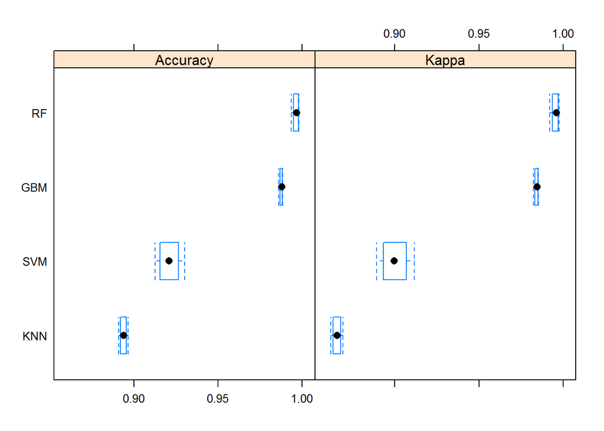

```r
bwplot(results)
```

#### It is evident from the summary data as well as the boxplots that the Random Forest (RF) model provides both the highest accuracy at identifying the test data and the highest Kappa value. For this reason we select the Random Forest as our predictive model. The most predictive model variables within the Random Forest algorithm are shown in the associated chart.

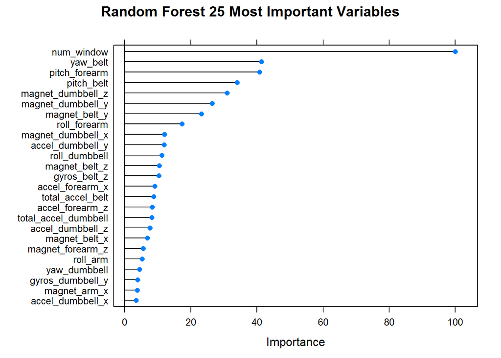

```r
## Best predictive model: Random Forest
plot(varImp(modelRF),top=25, main="Random Forest 25 Most Important Variables")
```

```r
predictRF <- predict(modelRF, workingTest)
confMatrix <- confusionMatrix(workingTest$classe,predictRF, dnn=c("Prediction","RF Model"))
confMatrix
```

```
## Confusion Matrix and Statistics
##
##           RF Model
## Prediction    A    B    C    D    E
##          A 1674    0    0    0    0
##          B    1 1138    0    0    0
##          C    0    6 1020    0    0
##          D    0    0    6  957    1
##          E    0    0    0    1 1081
##
## Overall Statistics
##
##                Accuracy : 0.9975
##                  95% CI : (0.9958, 0.9986)
##     No Information Rate : 0.2846
##     P-Value [Acc > NIR] : < 2.2e-16
##
##                   Kappa : 0.9968
##  Mcnemar's Test P-Value : NA
##
## Statistics by Class:
##
##                      Class: A Class: B Class: C Class: D Class: E
## Sensitivity            0.9994   0.9948   0.9942   0.9990   0.9991
## Specificity            1.0000   0.9998   0.9988   0.9986   0.9998
## Pos Pred Value         1.0000   0.9991   0.9942   0.9927   0.9991
## Neg Pred Value         0.9998   0.9987   0.9988   0.9998   0.9998
## Prevalence             0.2846   0.1944   0.1743   0.1628   0.1839
## Detection Rate         0.2845   0.1934   0.1733   0.1626   0.1837
## Detection Prevalence   0.2845   0.1935   0.1743   0.1638   0.1839
## Balanced Accuracy      0.9997   0.9973   0.9965   0.9988   0.9994
```

#### We can also see with the confusion matrix statistics that the predictive accuracy for this model is in excess of 99%: 0.9975, or 99.75% accurate, with an out-of-sample expected error of 0.25%.

#### The final out-of-sample prediction of class results is identified below.

[output not shown]